# Gráficos y su interprestación

```r
library(readr)
library(ggplot2)
library(gridExtra)
library(tidyverse)
library(lazyeval)
dataset <- read_csv("classification-results.csv")
dataset[,8:ncol(dataset)] <- round(dataset[,8:ncol(dataset)],digits = 3)
stations <- unique(dataset$var)
algoritmos <- unique(dataset$alg)
metrics <- c("FAR","Sensitivity","Specificity","Accuracy","Kappa","F1","Precision")
#' ## Carga dataset
#' Creación de dataset genérico para resultados clasificación
df <- dataset %>%
  unite(dataset,
        col=label,c("dataset","var","config.train","config.vars","T","alg"),
        sep = "-",remove=FALSE) %>%
  select(label,dataset,var,config.train,config.vars,T,alg,FAR,Sensitivity,Specificity,Accuracy,Kappa,F1,Precision)
```

Variabilidad de la Sensitivity por cada estación

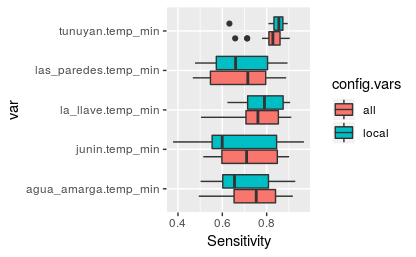

```r
p <-ggplot(aes(y = Sensitivity, x = var, fill = config.vars), data = df) +
  geom_boxplot()  + coord_flip()
print(p)
```

Los modelos con config-all presentaron mejor desempeño en sensitivity, excepto para Tunuyan y la Llave (este está parejo)

Variabilidad de la Sensitivity por según dataset usado

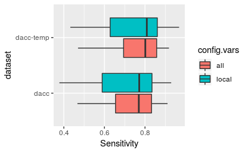

```r
p <-ggplot(aes(y = Sensitivity, x = dataset, fill = config.vars), data = df) +
  geom_boxplot()  + coord_flip()
print(p)
```

Variabilidad de F1 por según dataset usado

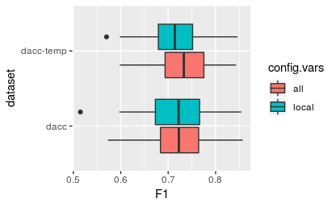

```r
p <-ggplot(aes(y = F1, x = dataset, fill = config.vars), data = df) +
  geom_boxplot()  + coord_flip()
print(p)
```

No se visualizan gran variabilidad entre los datasets usados entre F1, Sensitivity y precision

Variabilidad de Sensitivity según dataset usado

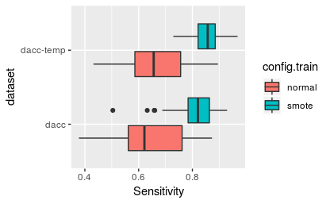

```r
p <-ggplot(aes(y = Sensitivity, x = dataset, fill = config.train), data = df) +
  geom_boxplot()  + coord_flip()
print(p)
```

SMOTE aumenta sensitivity en ambos datasets

Variabilidad de F1 por cada estación

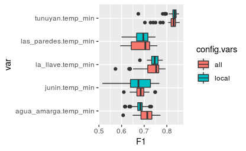

```r
p <-ggplot(aes(y = F1, x = var, fill = config.vars), data = df) + geom_boxplot() + coord_flip()
print(p)
```

Los modelos con config-all presentaron mejor desempeño en terminos medios de F1, excepto para Tunuyan y la Llave (este está parejo)

Variabilidad de precisión por cada estación

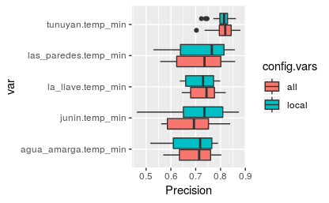

```r
p <-ggplot(aes(y = Precision , x = var, fill = config.vars), data = df) + geom_boxplot() + coord_flip()
print(p)
```

En términos medios la precision mejora en las Paredes y Junín con config-local. La llave, tunuyan y agua amarga “parejos”

Según cuántos días anteriores de información sumamos.

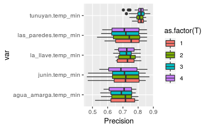

```r
#' ## Según cuantos días anteriores de información sumamos.
#'
p <-ggplot(aes(y = Precision , x = var, fill = as.factor(T)), data = df) + geom_boxplot() + coord_flip()
print(p)
```

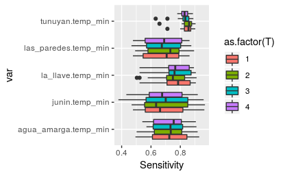

```r
p <-ggplot(aes(y = Sensitivity , x = var, fill = as.factor(T)), data = df) + geom_boxplot() + coord_flip()
print(p)
```

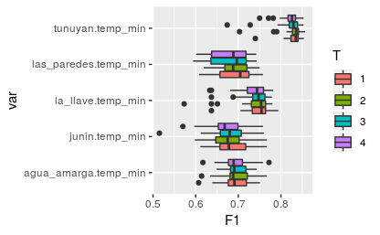

```r
p <-ggplot(aes(y = F1 , x = var, fill = as.factor(T)), data = df) +
  geom_boxplot() + coord_flip() + labs(fill="T")
print(p)
```

En general, con un día o dos se obtienen buenos resultados en términos de precision,recall y F1, ¿podría prescindirse de agregar más? Hay varios casos particulares, por ejemplo Agua amarga en sensitivity para T=1, su media es más baja respecto al T=2, sin embargo el máximo de sensitivity es con T=1.

Comparación normal vs smote por estación para métricas sensitivity y precision

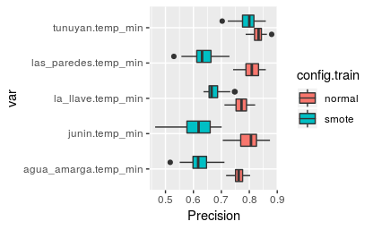

```r
p <-ggplot(aes(y = Precision , x = var, fill = config.train), data = df) + geom_boxplot() + coord_flip()
print(p)
```

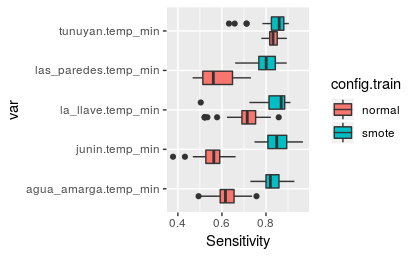

```r
p <-ggplot(aes(y = Sensitivity , x = var, fill = config.train), data = df) + geom_boxplot() + coord_flip()
print(p)
```

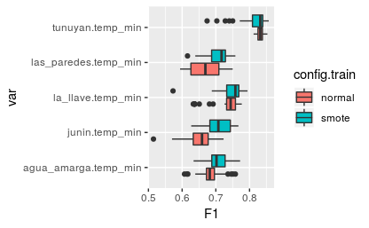

```r
p <-ggplot(aes(y = F1 , x = var, fill = config.train), data = df) + geom_boxplot() + coord_flip()
print(p)
```

La configuración SMoTE aumenta la sensitivity/F1 en detrimento de la precision. Es una consecuencia esperable.

Comportamiento general de local vs all de los algoritmos por cada estación según métrica

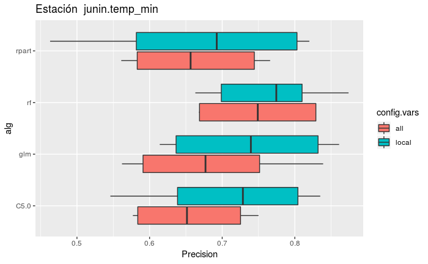

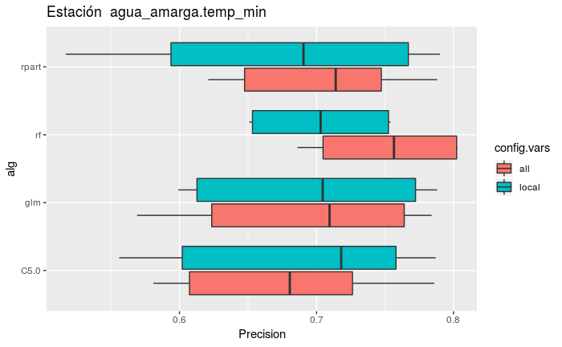

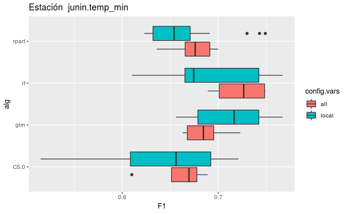

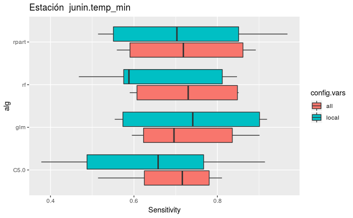

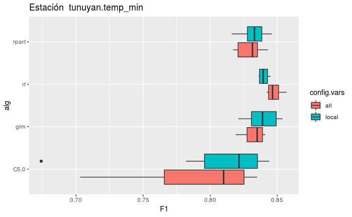

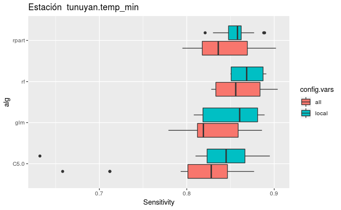

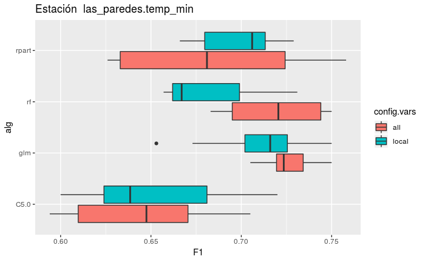

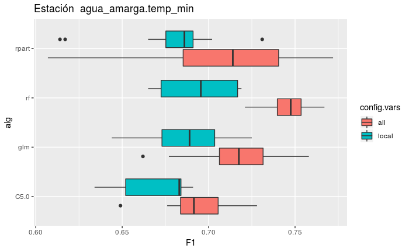

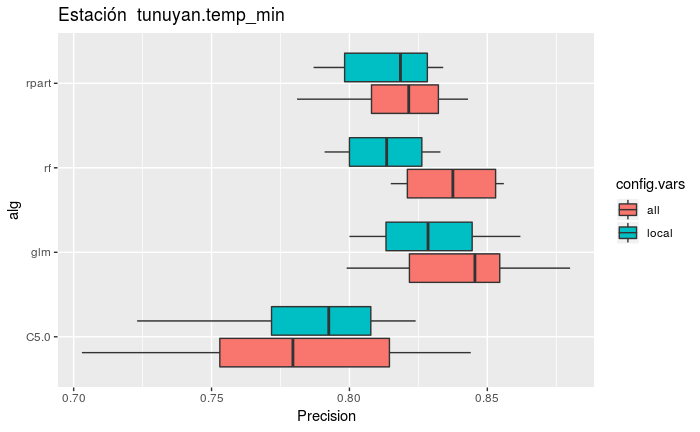

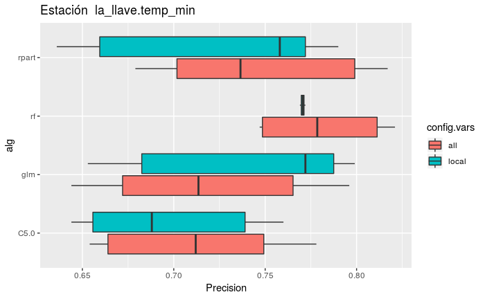

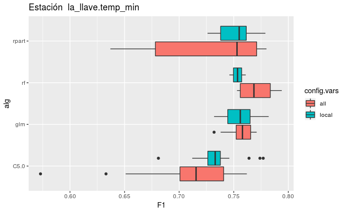

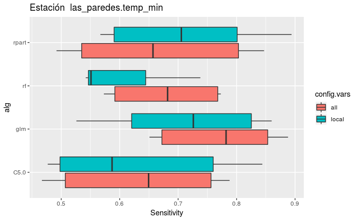

[3 more figures not shown]

```r
for(s in stations){

  df1 <- df %>% filter( var == s )

  p <-ggplot(aes(y = F1 , x = alg, fill = config.vars), data = df1) +
    geom_boxplot() + coord_flip() + labs(title=paste("Estación",s,sep="  "))
  print(p)
  p <-ggplot(aes(y = Sensitivity , x = alg, fill = config.vars), data = df1) +
    geom_boxplot() + coord_flip() + labs(title=paste("Estación",s,sep="  "))
  print(p)
  p <-ggplot(aes(y = Precision , x = alg, fill = config.vars), data = df1) +
    geom_boxplot() + coord_flip() + labs(title=paste("Estación",s,sep="  "))
  print(p)
}
```

```r
library(reshape)
df3 <-  df %>% filter( dataset == "dacc") %>% select(-one_of(c("FAR")))

#  melt(df3,id.vars="label")
df4 <- melt(as.data.frame(df3),
            id.vars =(c("label","dataset","var","config.train","config.vars","T","alg")),
            measure.vars = metrics[-1])

p <-ggplot(aes(y = value , x = var, fill = variable), data = df4) +
  geom_boxplot() + coord_flip() + labs(title="Variabilidad de las métricas por las estaciones")
print(p)

df4 <- df %>% filter( dataset == "dacc")
df4 <- melt(as.data.frame(df4),
            id.vars =(c("label","dataset","var","config.train","config.vars","T","alg")),
            measure.vars = metrics)

for(a in algoritmos)
{
  for(m in metrics)
  {
    df5 <- df4 %>% filter( alg == a & variable == m)
    p <-ggplot(aes(y = value , x = var, fill = config.vars), data = df5) +
      geom_boxplot() + coord_flip() + labs(title=paste("Comportamiento de ",m," en modelo ",a,sep=""))
    print(p)
  }
}
```

[output not shown]

Random forest

```r
df3 <- df %>%
      select(label,dataset,var,config.train,config.vars,T,alg,Sensitivity,Specificity,Accuracy,Kappa,F1,Precision) %>%
      filter( var == stations[1]  & alg==algoritmos[1]) # & T == 1 & dataset == DATASET &

df3
```

[output not shown]

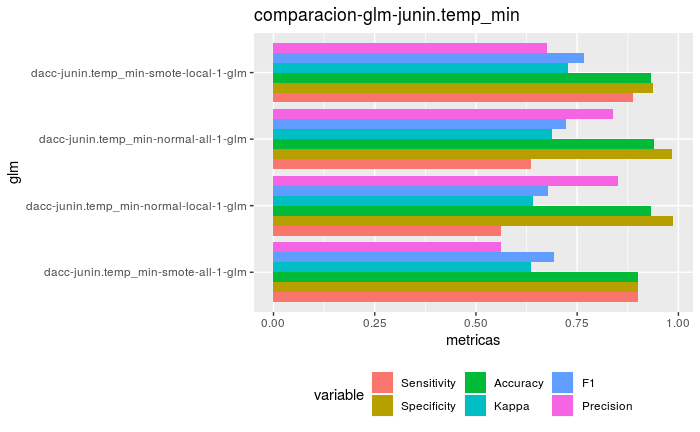

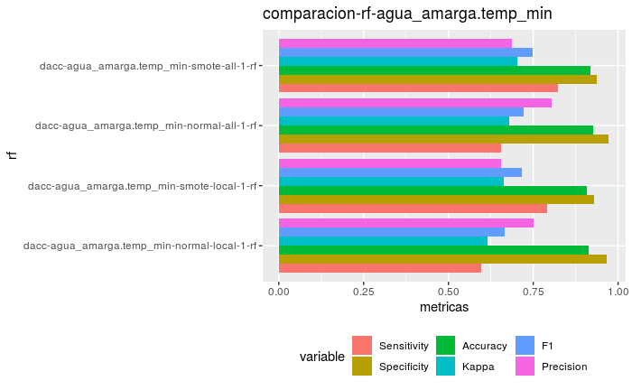

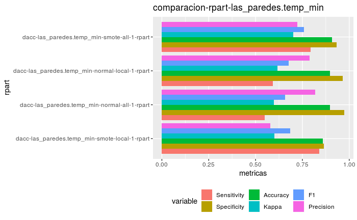

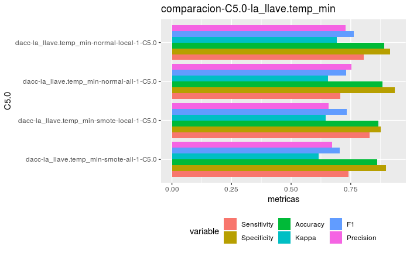

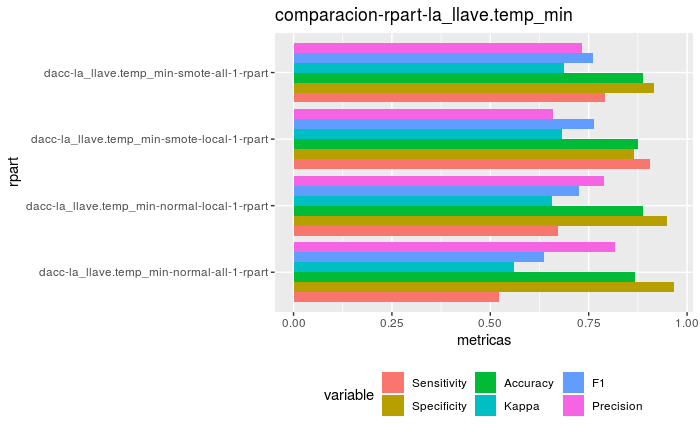

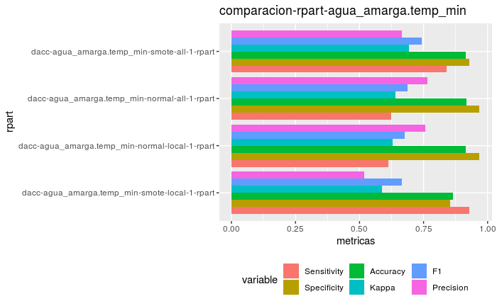

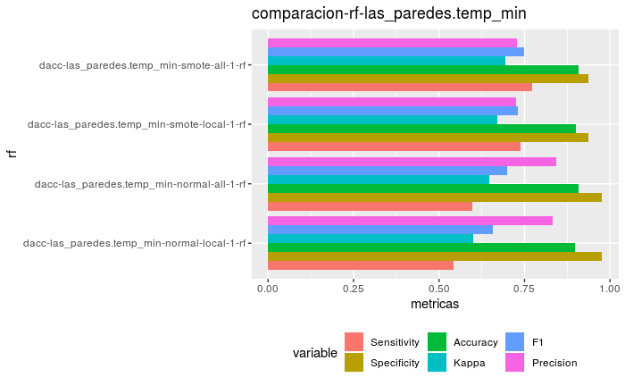

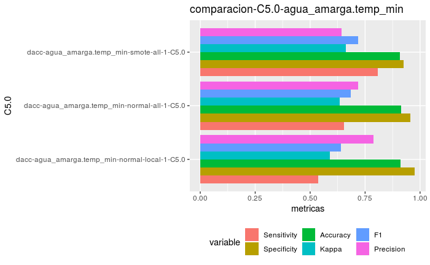

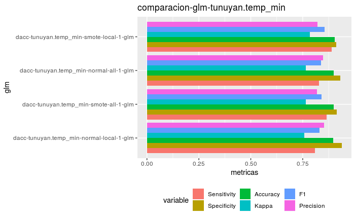

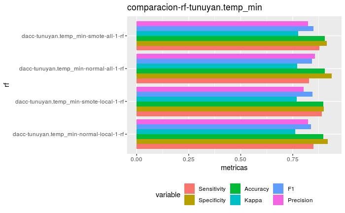

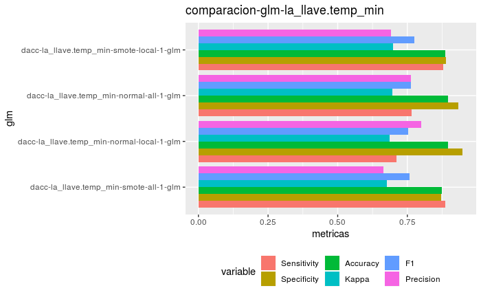

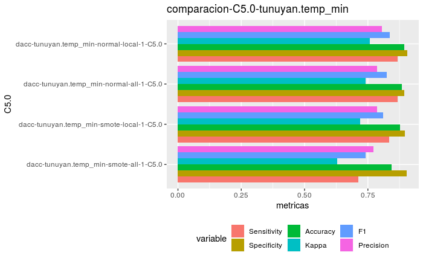

[8 more figures not shown]

```r
for(s in stations)
{
  for(a in algoritmos)
  {

    df3 <- df %>%
      select(label,dataset,var,config.train,config.vars,T,alg,Sensitivity,Specificity,Accuracy,Kappa,F1,Precision) %>%
      filter( var == s  & alg==a & T == 1 & dataset == "dacc") # &  # <- AQUI FILTRO

    df7 <- melt(as.data.frame(df3),id=(c("label","dataset","var","config.train","config.vars","T","alg")))


   p<-  ggplot(data=df7, aes(x= reorder(label,value), y=value, fill=variable)) +
      geom_bar(stat="identity",position=position_dodge())+
      coord_flip()+
      theme(legend.position="bottom") +
      labs(x = a, y = "metricas", title=paste("comparacion",a,s,sep="-"))
   print(p)

    # for(m in metrics){
    #   plot_ranking_alg(df3,m,s,a)
    #
    # }
  }
}
```

Filtramos para quedarnos con los modelos cuya Sensitivity y Precision haya sido mayor o igual a 0.7, observar el comportamiento por estación y algoritmo

Lo siguiente da error: verificar/chequear

```r
for(s in stations)
{
  for(a in algoritmos)
  {

    df3 <- df %>%
          select(label,dataset,var,config.train,config.vars,T,alg,Sensitivity,Precision,F1) %>% #,Specificity,Accuracy,Kappa,F1
          filter( Sensitivity > 0.7 , Precision > 0.7 , var==s, dataset == "dacc",alg==a ) # & T == 1 & dataset == DATASET &


    df7 <- melt(data.frame(df3),id=(c("label","dataset","var","config.train","config.vars","T","alg")))


    p<-  ggplot(data=df7, aes(x= label, y=value, fill=variable)) +
          geom_bar(stat="identity",position=position_dodge())+
          coord_flip()+
          theme(legend.position="bottom") +
          labs(title=paste("Estacion ",s," algoritmo ", a))
       print(p)
  }
}
```

```r
stations
```

```
[1] "tunuyan.temp_min"     "agua_amarga.temp_min" "junin.temp_min"       "la_llave.temp_min"    "las_paredes.temp_min"
```

Si queremos correr lo anterior fuera del for o bucle

```r
df3 <- df %>%
      select(label,dataset,var,config.train,config.vars,T,alg,Sensitivity,Precision) %>% #,Specificity,Accuracy,Kappa,F1
      filter( Sensitivity > 0.7 , Precision > 0.7 , var==stations[1], dataset == "dacc",alg=="rf" ) # & T == 1 & dataset == DATASET &

df7 <- melt(as.data.frame(df3),id=(c("label","dataset","var","config.train","config.vars","T","alg")))
```

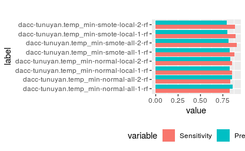

```r
p<-  ggplot(data=df7, aes(x= label, y=value, fill=variable)) +
      geom_bar(stat="identity",position=position_dodge())+
      coord_flip()+
      theme(legend.position="bottom") +
      labs(title="")
   print(p)
```